# Homework3

```r
# na.strings = "" will treat empty string as NA
loan_data <- read.csv('https://raw.githubusercontent.com/metis-macys-66898/data622_fa2021/main/hw3/data/Loan_approval.csv', header = TRUE, na.strings = "")

loan_raw <- read.csv('https://raw.githubusercontent.com/metis-macys-66898/data622_fa2021/main/hw3/data/Loan_approval.csv', header = TRUE)
```

## 1. Exploratory Data Analysis

Our loan data has 614 rows and 13 columns, 8 of which are categorical and 5 are numerical. The target variable is **Loan_Status**, which can be either **Y (yes)** or **N (no)**. This let’s us know if the applicant’s loan is approved. There are 7 variables that have blank values. The one with the most blank values is **Credit_History** with 50 blanks.

```r
loan_data %>% kbl() %>% kable_styling() %>% scroll_box(width = "750px", height = "250px")
```

| Loan_ID | Gender | Married | Dependents | Education | Self_Employed | ApplicantIncome | CoapplicantIncome | LoanAmount | Loan_Amount_Term | Credit_History | Property_Area | Loan_Status |
| --- | --- | --- | --- | --- | --- | --- | --- | --- | --- | --- | --- | --- |
| LP001002 | Male | No | 0 | Graduate | No | 5849 | 0.00 | NA | 360 | 1 | Urban | Y |
| LP001003 | Male | Yes | 1 | Graduate | No | 4583 | 1508.00 | 128 | 360 | 1 | Rural | N |
| LP001005 | Male | Yes | 0 | Graduate | Yes | 3000 | 0.00 | 66 | 360 | 1 | Urban | Y |
| LP001006 | Male | Yes | 0 | Not Graduate | No | 2583 | 2358.00 | 120 | 360 | 1 | Urban | Y |
| LP001008 | Male | No | 0 | Graduate | No | 6000 | 0.00 | 141 | 360 | 1 | Urban | Y |
| LP001011 | Male | Yes | 2 | Graduate | Yes | 5417 | 4196.00 | 267 | 360 | 1 | Urban | Y |
| LP001013 | Male | Yes | 0 | Not Graduate | No | 2333 | 1516.00 | 95 | 360 | 1 | Urban | Y |
| LP001014 | Male | Yes | 3+ | Graduate | No | 3036 | 2504.00 | 158 | 360 | 0 | Semiurban | N |
| LP001018 | Male | Yes | 2 | Graduate | No | 4006 | 1526.00 | 168 | 360 | 1 | Urban | Y |
| LP001020 | Male | Yes | 1 | Graduate | No | 12841 | 10968.00 | 349 | 360 | 1 | Semiurban | N |
| LP001024 | Male | Yes | 2 | Graduate | No | 3200 | 700.00 | 70 | 360 | 1 | Urban | Y |
| LP001027 | Male | Yes | 2 | Graduate | NA | 2500 | 1840.00 | 109 | 360 | 1 | Urban | Y |
| LP001028 | Male | Yes | 2 | Graduate | No | 3073 | 8106.00 | 200 | 360 | 1 | Urban | Y |
| LP001029 | Male | No | 0 | Graduate | No | 1853 | 2840.00 | 114 | 360 | 1 | Rural | N |
| LP001030 | Male | Yes | 2 | Graduate | No | 1299 | 1086.00 | 17 | 120 | 1 | Urban | Y |
| LP001032 | Male | No | 0 | Graduate | No | 4950 | 0.00 | 125 | 360 | 1 | Urban | Y |
| LP001034 | Male | No | 1 | Not Graduate | No | 3596 | 0.00 | 100 | 240 | NA | Urban | Y |
| LP001036 | Female | No | 0 | Graduate | No | 3510 | 0.00 | 76 | 360 | 0 | Urban | N |
| LP001038 | Male | Yes | 0 | Not Graduate | No | 4887 | 0.00 | 133 | 360 | 1 | Rural | N |
| LP001041 | Male | Yes | 0 | Graduate | NA | 2600 | 3500.00 | 115 | NA | 1 | Urban | Y |
| LP001043 | Male | Yes | 0 | Not Graduate | No | 7660 | 0.00 | 104 | 360 | 0 | Urban | N |
| LP001046 | Male | Yes | 1 | Graduate | No | 5955 | 5625.00 | 315 | 360 | 1 | Urban | Y |
| LP001047 | Male | Yes | 0 | Not Graduate | No | 2600 | 1911.00 | 116 | 360 | 0 | Semiurban | N |
| LP001050 | NA | Yes | 2 | Not Graduate | No | 3365 | 1917.00 | 112 | 360 | 0 | Rural | N |
| LP001052 | Male | Yes | 1 | Graduate | NA | 3717 | 2925.00 | 151 | 360 | NA | Semiurban | N |
| LP001066 | Male | Yes | 0 | Graduate | Yes | 9560 | 0.00 | 191 | 360 | 1 | Semiurban | Y |
| LP001068 | Male | Yes | 0 | Graduate | No | 2799 | 2253.00 | 122 | 360 | 1 | Semiurban | Y |
| LP001073 | Male | Yes | 2 | Not Graduate | No | 4226 | 1040.00 | 110 | 360 | 1 | Urban | Y |
| LP001086 | Male | No | 0 | Not Graduate | No | 1442 | 0.00 | 35 | 360 | 1 | Urban | N |
| LP001087 | Female | No | 2 | Graduate | NA | 3750 | 2083.00 | 120 | 360 | 1 | Semiurban | Y |

[output cut: 584 more lines]

```r
summary(loan_data) %>% kbl() %>% kable_styling() %>% scroll_box(width = "750px", height = "250px")
```

|  | Loan_ID | Gender | Married | Dependents | Education | Self_Employed | ApplicantIncome | CoapplicantIncome | LoanAmount | Loan_Amount_Term | Credit_History | Property_Area | Loan_Status |
| --- | --- | --- | --- | --- | --- | --- | --- | --- | --- | --- | --- | --- | --- |
|  | Length:614 | Length:614 | Length:614 | Length:614 | Length:614 | Length:614 | Min. : 150 | Min. : 0 | Min. : 9.0 | Min. : 12 | Min. :0.0000 | Length:614 | Length:614 |
|  | Class :character | Class :character | Class :character | Class :character | Class :character | Class :character | 1st Qu.: 2878 | 1st Qu.: 0 | 1st Qu.:100.0 | 1st Qu.:360 | 1st Qu.:1.0000 | Class :character | Class :character |
|  | Mode :character | Mode :character | Mode :character | Mode :character | Mode :character | Mode :character | Median : 3812 | Median : 1188 | Median :128.0 | Median :360 | Median :1.0000 | Mode :character | Mode :character |
|  | NA | NA | NA | NA | NA | NA | Mean : 5403 | Mean : 1621 | Mean :146.4 | Mean :342 | Mean :0.8422 | NA | NA |
|  | NA | NA | NA | NA | NA | NA | 3rd Qu.: 5795 | 3rd Qu.: 2297 | 3rd Qu.:168.0 | 3rd Qu.:360 | 3rd Qu.:1.0000 | NA | NA |
|  | NA | NA | NA | NA | NA | NA | Max. :81000 | Max. :41667 | Max. :700.0 | Max. :480 | Max. :1.0000 | NA | NA |
|  | NA | NA | NA | NA | NA | NA | NA | NA | NA’s :22 | NA’s :14 | NA’s :50 | NA | NA |

```r
missing <- loan_data %>% mutate_if(is.character, list(~na_if(.,"")))

missing%>%
  summarise_all(list(~sum(is.na(.)))) %>%
  gather(key="Variable", value="Number_Missing") %>%
  arrange(desc(Number_Missing)) %>% kbl() %>% kable_styling() %>% scroll_box(width = "750px", height = "250px")
```

| Variable | Number_Missing |
| --- | --- |
| Credit_History | 50 |
| Self_Employed | 32 |
| LoanAmount | 22 |
| Dependents | 15 |
| Loan_Amount_Term | 14 |
| Gender | 13 |
| Married | 3 |
| Loan_ID | 0 |
| Education | 0 |
| ApplicantIncome | 0 |
| CoapplicantIncome | 0 |
| Property_Area | 0 |
| Loan_Status | 0 |

### Factors

```r
loan_data <- loan_data %>% mutate_if(is.character, factor)
```

### The following section we’ll continue to look at the data from the raw perspective (loan_raw).

### **Categorical Variables**

There are several variables which have blank values "". These data points may have been intentionally skipped by customers from banks during the data collection process or they may just be missing. We will handle this later on.  
* **Loan_ID:** unique identifier  
* **Gender:** either Male or Female or blank  
* **Married:** either No or Yes or blank  
* **Dependents:** how many dependents does someone have? 0, 1, 2, 3+ or blank  
* **Education:** Graduate or Not Graduate  
* **Self_Employed:** No or Yes or blank  
* **Property_Area:** Urban, Rural or Semiurban  
* **Loan_status:** Y (yes) or N (no)  
* **Credit_History:** does the credit history meet the guidelines? 1 = Yes, 0 = No

#### Married

Married applicants have a higher approval rate than non married applicants. It will be useful to look into if this has any correlation with income.

```r
married_loan_status_count <- table(loan_raw$Married,loan_raw$Loan_Status)
married_loan_status_perct <- married_loan_status_count
married_loan_status_perct[1,] <- round(married_loan_status_perct[1,]/3 * 100, 2)
married_loan_status_perct[2,] <- round(married_loan_status_perct[2,]/213 * 100, 2)
married_loan_status_perct[3,] <- round(married_loan_status_perct[3,]/398 * 100, 2)

#set column names for married_loan_status_count
married_loan_status_count <- data.frame(married_loan_status_count)
colnames(married_loan_status_count) <- c('Married','Loan_Status','Count')

#set column names and row names for gender_loan_status_perct
rownames(married_loan_status_perct) <-  c("Blank", "Not Married", "Married")
colnames(married_loan_status_perct) <-  c("% Applications Not Approved", "% Applications Approved")

loan_data_Married <- loan_raw
loan_data_Married[loan_data_Married$Married == '',] <- "Blank"

t1 <- loan_data_Married %>% group_by(Married) %>% tally
colnames(t1) <- c("Married","Count Loan Applications")
t2 <- married_loan_status_perct

knitr::kable(list(t1, t2))
```

| Married | Count Loan Applications |
| --- | --- |
| Blank | 3 |
| No | 213 |
| Yes | 398 |

|  | % Applications Not Approved | % Applications Approved |
| --- | --- | --- |
| Blank | 0.00 | 100.00 |
| Not Married | 37.09 | 62.91 |
| Married | 28.39 | 71.61 |

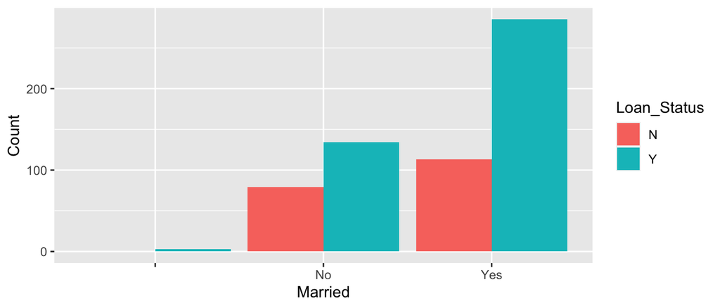

```r
ggplot(data=married_loan_status_count, aes(x=Married, y=Count, fill=Loan_Status)) + geom_bar(stat="identity",position="dodge")
```

#### Dependents

Applicants with 2 dependents appear to have the highest loan approval rate. It’d be interesting to see if the income per dependent has any impact on loan approval if we assume having more income makes it more likely to get a loan approved.

```r
dep_loan_status_count <- table(loan_raw$Dependents,loan_raw$Loan_Status)
dep_loan_status_perct <- dep_loan_status_count
dep_loan_status_perct[1,] <- round(dep_loan_status_perct[1,]/15 * 100, 2)
dep_loan_status_perct[2,] <- round(dep_loan_status_perct[2,]/345 * 100, 2)
dep_loan_status_perct[3,] <- round(dep_loan_status_perct[3,]/102 * 100, 2)
dep_loan_status_perct[4,] <- round(dep_loan_status_perct[4,]/101 * 100, 2)
dep_loan_status_perct[5,] <- round(dep_loan_status_perct[5,]/51 * 100, 2)

#set column names for dep_loan_status_count
dep_loan_status_count <- data.frame(dep_loan_status_count)
colnames(dep_loan_status_count) <- c('Dependents','Loan_Status','Count')

#set column names and row names for gender_loan_status_perct
rownames(dep_loan_status_perct) <-  c("Blank", "0", "1","2","3+")
colnames(dep_loan_status_perct) <-  c("% Applications Not Approved", "% Applications Approved")

loan_data_Dep <- loan_raw
loan_data_Dep[loan_data_Dep$Dependents == '',] <- "Blank"

t1 <- loan_data_Dep %>% group_by(Dependents) %>% tally
colnames(t1) <- c("Dependents","Count Loan Applications")
t2 <- dep_loan_status_perct

knitr::kable(list(t1, t2))
```

| Dependents | Count Loan Applications |
| --- | --- |
| 0 | 345 |
| 1 | 102 |
| 2 | 101 |
| 3+ | 51 |
| Blank | 15 |

|  | % Applications Not Approved | % Applications Approved |
| --- | --- | --- |
| Blank | 40.00 | 60.00 |
| 0 | 31.01 | 68.99 |
| 1 | 35.29 | 64.71 |
| 2 | 24.75 | 75.25 |
| 3+ | 35.29 | 64.71 |

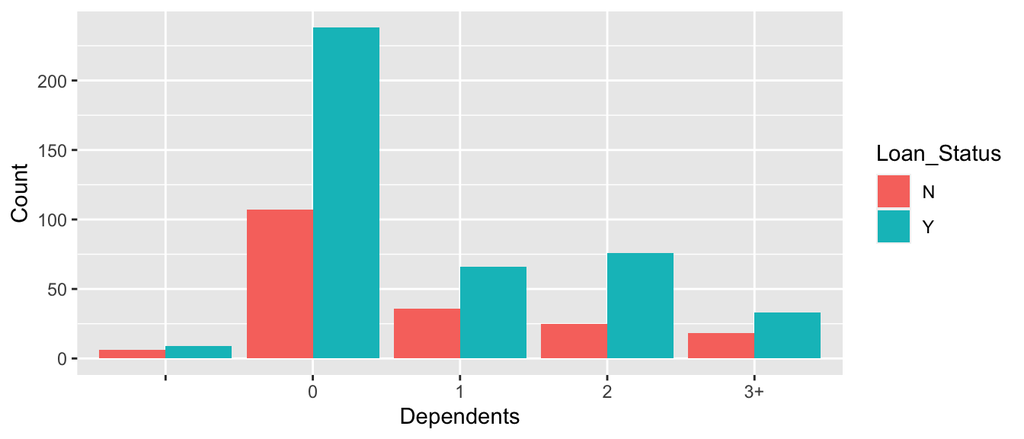

```r
ggplot(data=dep_loan_status_count, aes(x=Dependents, y=Count, fill=Loan_Status)) + geom_bar(stat="identity",position="dodge")
```

#### Education

Applicants with Graduate education have a higher loan approval rate here.

```r
edu_loan_status_count <- table(loan_raw$Education,loan_raw$Loan_Status)
edu_loan_status_perct <- edu_loan_status_count
edu_loan_status_perct[1,] <- round(edu_loan_status_perct[1,]/480 * 100, 2)
edu_loan_status_perct[2,] <- round(edu_loan_status_perct[2,]/134 * 100, 2)

#set column names for edu_loan_status_count
edu_loan_status_count <- data.frame(edu_loan_status_count)
colnames(edu_loan_status_count) <- c('Education','Loan_Status','Count')

#set column names for edu_loan_status_perct
colnames(edu_loan_status_perct) <-  c("% Applications Not Approved", "% Applications Approved")

t1 <- loan_raw %>% group_by(Education) %>% tally
colnames(t1) <- c("Education","Count Loan Applications")
t2 <- edu_loan_status_perct

knitr::kable(list(t1, t2))
```

| Education | Count Loan Applications |
| --- | --- |
| Graduate | 480 |
| Not Graduate | 134 |

|  | % Applications Not Approved | % Applications Approved |
| --- | --- | --- |
| Graduate | 29.17 | 70.83 |
| Not Graduate | 38.81 | 61.19 |

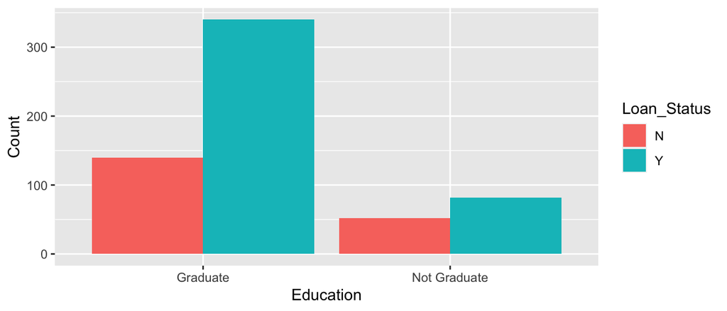

```r
ggplot(data=edu_loan_status_count, aes(x=Education, y=Count, fill=Loan_Status)) + geom_bar(stat="identity",position="dodge")
```

#### Property Area

Semiurban applicants have the highest approval loan rating over rural and urban.

```r
proparea_loan_status_count <- table(loan_raw$Property_Area,loan_raw$Loan_Status)
proparea_loan_status_perct <- proparea_loan_status_count
proparea_loan_status_perct[1,] <- round(proparea_loan_status_perct[1,]/179  * 100, 2)
proparea_loan_status_perct[2,] <- round(proparea_loan_status_perct[2,]/233  * 100, 2)
proparea_loan_status_perct[3,] <- round(proparea_loan_status_perct[3,]/202  * 100, 2)

#set column names for proparea_loan_status_count
proparea_loan_status_count <- data.frame(proparea_loan_status_count)
colnames(proparea_loan_status_count) <- c('Property_Area','Loan_Status','Count')

#set column names for proparea_loan_status_perct
colnames(proparea_loan_status_perct) <-  c("% Applications Not Approved", "% Applications Approved")

t1 <- loan_raw %>% group_by(Property_Area) %>% tally
colnames(t1) <- c("Property_Area","Count Loan Applications")
t2 <- proparea_loan_status_perct

knitr::kable(list(t1, t2))
```

| Property_Area | Count Loan Applications |
| --- | --- |
| Rural | 179 |
| Semiurban | 233 |
| Urban | 202 |

|  | % Applications Not Approved | % Applications Approved |
| --- | --- | --- |
| Rural | 38.55 | 61.45 |
| Semiurban | 23.18 | 76.82 |
| Urban | 34.16 | 65.84 |

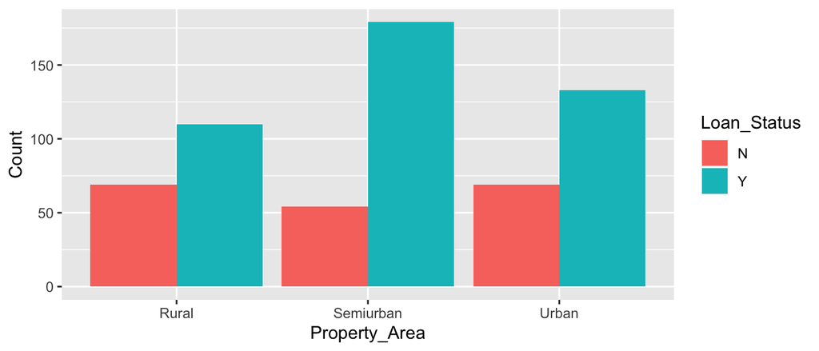

```r
ggplot(data=proparea_loan_status_count, aes(x=Property_Area, y=Count, fill=Loan_Status)) + geom_bar(stat="identity",position="dodge")
```

#### Credit History

Having an a credit history that meets the guidelines appears to be extremely important in whether the loan status is approved or not.

```r
credhist_loan_status_count <- table(loan_raw$Credit_History,loan_raw$Loan_Status)
credhist_loan_status_perct <- credhist_loan_status_count
credhist_loan_status_perct[1,] <- round(credhist_loan_status_perct[1,]/89  * 100, 2)
credhist_loan_status_perct[2,] <- round(credhist_loan_status_perct[2,]/475  * 100, 2)

#set column names for credhist_loan_status_count
credhist_loan_status_count <- data.frame(credhist_loan_status_count)
colnames(credhist_loan_status_count) <- c('Credit_History','Loan_Status','Count')

#set column names for credhist_loan_status_perct
colnames(credhist_loan_status_perct) <-  c("% Applications Not Approved", "% Applications Approved")

t1 <- loan_raw %>% group_by(Credit_History) %>% tally
colnames(t1) <- c("Credit_History","Count Loan Applications")
t2 <- credhist_loan_status_perct

knitr::kable(list(t1, t2))
```

| Credit_History | Count Loan Applications |
| --- | --- |
| 0 | 89 |
| 1 | 475 |
| NA | 50 |

|  | % Applications Not Approved | % Applications Approved |
| --- | --- | --- |
| 0 | 92.13 | 7.87 |
| 1 | 20.42 | 79.58 |

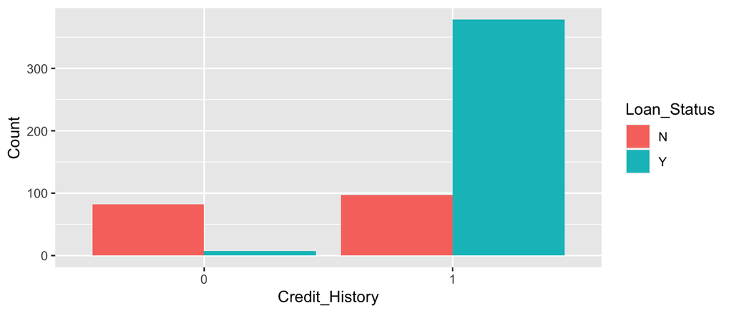

```r
ggplot(data=credhist_loan_status_count, aes(x=Credit_History, y=Count, fill=Loan_Status)) + geom_bar(stat="identity",position="dodge")
```

### **Numerical Variables**

- **ApplicantIncome:** how much money does the applicant make?
- **CoapplicantIncome:** how much money does the coapplicant make? if there is no coapplicant this is 0.
- **LoanAmount:** how much is the loan worth in thousands?
- **Loan_Amount_Term:** how many months is the loan?

Now let’s use the **pairs.panels** function to see a lot of important information related to our numeric data:

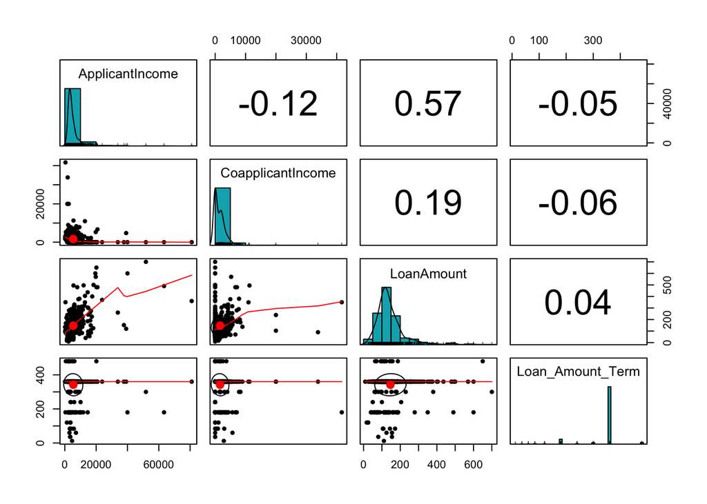

```r
numeric_loan_data <- dplyr::select(loan_data,ApplicantIncome,CoapplicantIncome,LoanAmount,Loan_Amount_Term)
pairs.panels(numeric_loan_data,
             method = "pearson", # correlation method
             hist.col = "#00AFBB",
             density = TRUE,  # show density plots
             ellipses = TRUE # show correlation ellipses
             )
```

#### Inspecting ApplicantIncome and Loan Income

Here we can see that the **ApplicantIncome** does not have a huge effect on whether the Loan_Status was approved (Y) or not. The average ApplicantIncome is about the same for both groups is similar. There are a fewer more outliers of high incomes in the group where the loan status was approved.

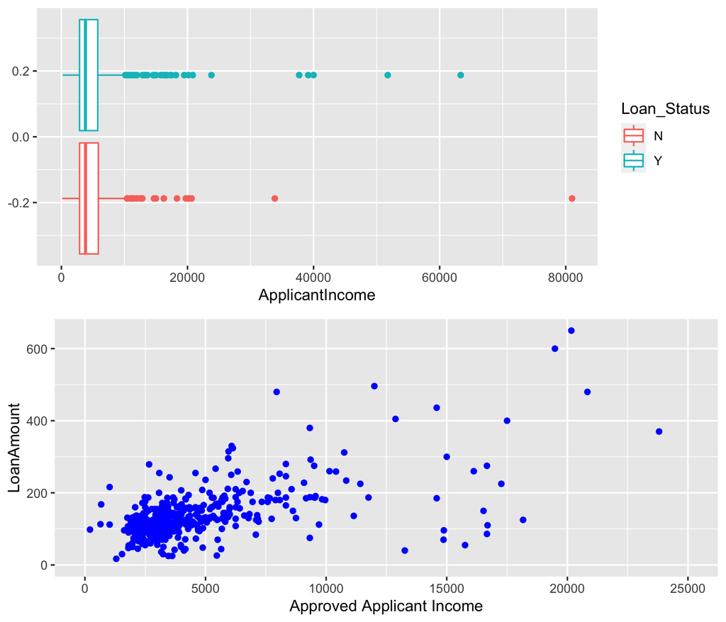

```r
approved <- loan_data[loan_data$Loan_Status == 'Y',]
denied <- loan_data[loan_data$Loan_Status == 'N',]

a <- ggplot(loan_data,aes(x=ApplicantIncome,color=Loan_Status))  + geom_boxplot()
b <- ggplot(approved,aes(x=ApplicantIncome,y=LoanAmount,color=Loan_Status)) + geom_point(color='blue') + xlab('Approved Applicant Income') + scale_x_continuous(limits = c(0, 25000)) + scale_y_continuous(limits = c(0, 650))
grid.arrange(a,b,nrow=2)#,nrow=2,ncol=2,layout_matrix=c(1,1,2,3))
```

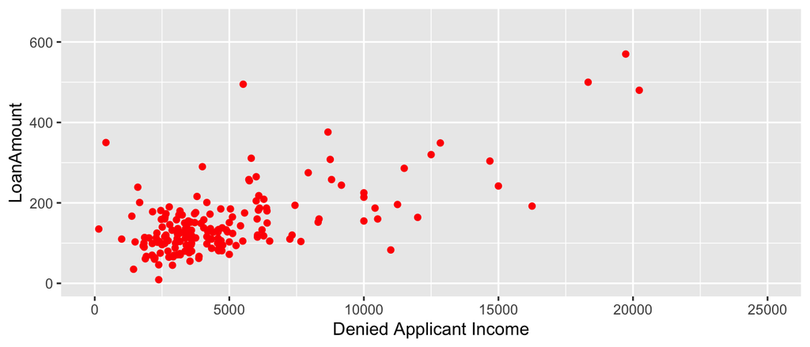

```r
c <- ggplot(denied,aes(x=ApplicantIncome,y=LoanAmount,color=Loan_Status)) + geom_point(color='red') + xlab('Denied Applicant Income') + scale_x_continuous(limits = c(0, 25000)) + scale_y_continuous(limits = c(0, 650))

grid.arrange(c)
```

In addition, upon investigating the sum of **ApplicantIncome** and **CoapplicantIncome**, we observe that it does not appear to have much prediction power with **Loan_Status**.

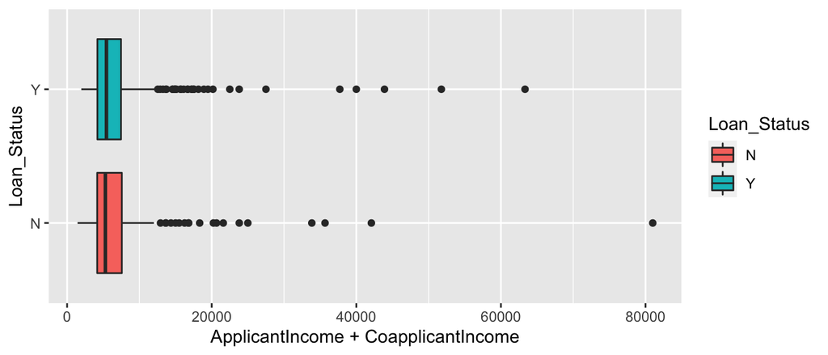

```r
ggplot(data = loan_data, aes(x = Loan_Status, y = ApplicantIncome+CoapplicantIncome, fill=Loan_Status)) +
  geom_boxplot() +
  coord_flip()
```

#### LoanAmount Per ApplicantIncome

Now let’s see if the rate of the **LoanAmount** divided by **ApplicantIncome** has any prediction power when trying to deteremine if a Loan_Status will be approved or not. This would indicate that perhaps someone who is requesting a LoanAmount 5 times their income, they might not be approved but if they requested 3 times their income they could get approved.

Looking at the boxplots below, the average LoanAmtPerSalary is roughly the same for approved and not approved applications so this disbunks this theory. This variable might prove helpful in our modeling so we will keep it.

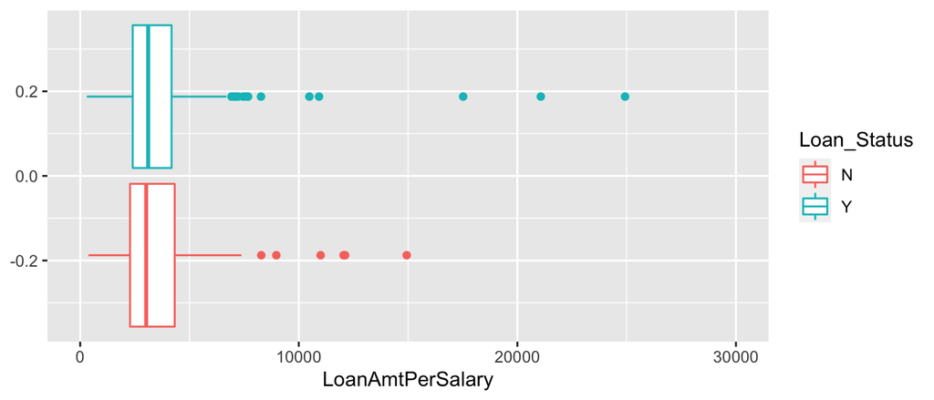

```r
loan_data$LoanAmtPerSalary <- loan_data$LoanAmount*100000/loan_data$ApplicantIncome
ggplot(loan_data,aes(x=LoanAmtPerSalary,color=Loan_Status)) + geom_boxplot() + scale_x_continuous(limits = c(0, 30000))
```

## Data Prep for Model-fitting

I explicitly recoded the Y/N values into 1/0’s

## Additional Data Processing / Manipulation Steps

So, first off, I need to convert Credit_History to factors so that the mice model that I’m going to use can detect that column as a categorical variable.

Combining ApplicantIncome and CoapplicantIncome into a new variable TotalIncome, and dropping the respective input columns. Loan_ID doesn’t help with the prediction obviously. So dropping it as well.

```r
loan_knn_pre_imp <- loan_knn
loan_knn_pre_imp$Credit_History <- as.factor(loan_knn_pre_imp$Credit_History)

loan_knn_pre_imp <- loan_knn_pre_imp %>% mutate(TotalIncome = ApplicantIncome + CoapplicantIncome)
loan_knn_pre_imp <- loan_knn_pre_imp %>% dplyr::select(-c('Loan_ID','ApplicantIncome','CoapplicantIncome'))

# loan_knn_pre_imp[loan_knn_pre_imp$Dependents = "3+"] <- "3"

# recode dependents 3+ to 3
loan_knn_pre_imp$Dependents <- revalue(loan_knn_pre_imp$Dependents, c("3+"="3"))


str(loan_knn_pre_imp)
```

```
## 'data.frame':    614 obs. of  12 variables:
##  $ Gender          : Factor w/ 2 levels "Female","Male": 2 2 2 2 2 2 2 2 2 2 ...
##  $ Married         : Factor w/ 2 levels "No","Yes": 1 2 2 2 1 2 2 2 2 2 ...
##  $ Dependents      : Factor w/ 4 levels "0","1","2","3": 1 2 1 1 1 3 1 4 3 2 ...
##  $ Education       : Factor w/ 2 levels "Graduate","Not Graduate": 1 1 1 2 1 1 2 1 1 1 ...
##  $ Self_Employed   : Factor w/ 2 levels "No","Yes": 1 1 2 1 1 2 1 1 1 1 ...
##  $ LoanAmount      : int  NA 128 66 120 141 267 95 158 168 349 ...
##  $ Loan_Amount_Term: int  360 360 360 360 360 360 360 360 360 360 ...
##  $ Credit_History  : Factor w/ 2 levels "0","1": 2 2 2 2 2 2 2 1 2 2 ...
##  $ Property_Area   : Factor w/ 3 levels "Rural","Semiurban",..: 3 1 3 3 3 3 3 2 3 2 ...
##  $ Loan_Status     : num  1 0 1 1 1 1 1 0 1 0 ...
##  $ LoanAmtPerSalary: num  NA 2793 2200 4646 2350 ...
##  $ TotalIncome     : num  5849 6091 3000 4941 6000 ...
```

### Status quo of missing data

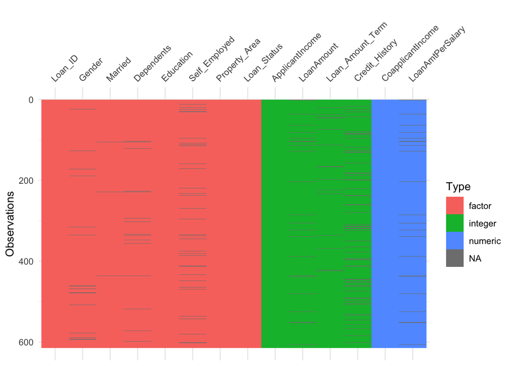

```r
clean_loan_data <- loan_data

vis_dat(clean_loan_data)
```

I’ve set up a predictorMatrix where I can instruct mice to use which method for which column for imputation.

Set seed = 501. Retrieved the results.

```r
# clean_loan_data <- complete(mice(clean_loan_data,m=5,meth='pmm',print=FALSE))
init <- mice(loan_knn_pre_imp, maxit=0)
meth <- init$method
predM <- init$predictorMatrix
meth[c('LoanAmount','Loan_Amount_Term')] <- 'norm'
meth[c('Credit_History','Self_Employed','Gender','Married')] <- 'logreg'
meth[c('Dependents')] <- 'polyreg'
meth[c('Loan_Status','TotalIncome','Property_Area','Education')] = ''
loan_knn_imp1 <- mice(loan_knn_pre_imp, method=meth, predictorMatrix=predM, seed=501)
```

### Manual Examinations

After some manual examinations of the different imputed results, I’ve decided to go with imputed column #3.

```r
# Manual examination
#Credit_History
loan_knn_imp1$imp$Credit_History
```

```
##     1 2 3 4 5
## 17  1 1 1 1 1
## 25  0 1 1 0 1
## 31  1 1 1 1 1
## 43  1 1 1 1 1
## 80  1 1 1 1 1
## 84  0 0 1 0 0
## 87  1 1 1 1 1
## 96  0 0 1 0 1
## 118 1 1 1 1 1
## 126 1 1 1 1 1
## 130 1 0 1 0 1
## 131 1 1 1 1 1
## 157 1 1 1 1 1
## 182 0 1 1 0 1
## 188 1 1 1 1 1
## 199 1 1 1 1 1
## 220 1 1 1 1 1
## 237 1 0 0 1 1
## 238 1 1 1 1 1
## 260 0 0 1 1 0
##  [ reached 'max' / getOption("max.print") -- omitted 30 rows ]
```

```r
loan_knn[96:118,]
```

```
##      Loan_ID Gender Married Dependents    Education Self_Employed
## 96  LP001326   Male      No          0     Graduate          <NA>
## 97  LP001327 Female     Yes          0     Graduate            No
## 98  LP001333   Male     Yes          0     Graduate            No
## 99  LP001334   Male     Yes          0 Not Graduate            No
## 100 LP001343   Male     Yes          0     Graduate            No
## 101 LP001345   Male     Yes          2 Not Graduate            No
## 102 LP001349   Male      No          0     Graduate            No
##     ApplicantIncome CoapplicantIncome LoanAmount Loan_Amount_Term
## 96             6782                 0         NA              360
## 97             2484              2302        137              360
## 98             1977               997         50              360
## 99             4188                 0        115              180
## 100            1759              3541        131              360
## 101            4288              3263        133              180
## 102            4843              3806        151              360
##     Credit_History Property_Area Loan_Status LoanAmtPerSalary
## 96              NA         Urban           0               NA
## 97               1     Semiurban           1         5515.298
## 98               1     Semiurban           1         2529.084
## 99               1     Semiurban           1         2745.941
## 100              1     Semiurban           1         7447.413
## 101              1         Urban           1         3101.679
## 102              1     Semiurban           1         3117.902
##  [ reached 'max' / getOption("max.print") -- omitted 16 rows ]
```

```r
#Married
loan_knn_imp1$imp$Married
```

```
##       1   2   3   4   5
## 105 Yes Yes Yes  No Yes
## 229  No Yes Yes Yes Yes
## 436 Yes Yes  No  No  No
```

```r
loan_knn[430:436,]
```

```
##      Loan_ID Gender Married Dependents    Education Self_Employed
## 430 LP002370   Male      No          0 Not Graduate            No
## 431 LP002377 Female      No          1     Graduate           Yes
## 432 LP002379   Male      No          0     Graduate            No
## 433 LP002386   Male      No          0     Graduate          <NA>
## 434 LP002387   Male     Yes          0     Graduate            No
## 435 LP002390   Male      No          0     Graduate            No
## 436 LP002393 Female    <NA>       <NA>     Graduate            No
##     ApplicantIncome CoapplicantIncome LoanAmount Loan_Amount_Term
## 430            2717                 0         60              180
## 431            8624                 0        150              360
## 432            6500                 0        105              360
## 433           12876                 0        405              360
## 434            2425              2340        143              360
## 435            3750                 0        100              360
## 436           10047                 0         NA              240
##     Credit_History Property_Area Loan_Status LoanAmtPerSalary
## 430              1         Urban           1         2208.318
## 431              1     Semiurban           1         1739.332
## 432              0         Rural           0         1615.385
## 433              1     Semiurban           1         3145.387
## 434              1     Semiurban           1         5896.907
## 435              1         Urban           1         2666.667
## 436              1     Semiurban           1               NA
```

```r
#Dependents
loan_knn_imp1$imp$Dependents
```

```
##     1 2 3 4 5
## 103 2 1 3 1 0
## 105 0 3 0 2 0
## 121 2 2 3 2 0
## 227 2 2 1 1 1
## 229 0 0 2 1 2
## 294 0 0 3 0 0
## 302 0 0 1 3 1
## 333 0 0 0 0 0
## 336 0 0 1 2 2
## 347 0 0 3 0 1
## 356 1 0 0 0 0
## 436 2 2 0 0 0
## 518 0 2 0 1 2
## 572 0 0 1 1 2
## 598 0 0 0 0 0
```

```r
loan_knn[227:229,]
```

```
##      Loan_ID Gender Married Dependents    Education Self_Employed
## 227 LP001754   Male     Yes       <NA> Not Graduate           Yes
## 228 LP001758   Male     Yes          2     Graduate            No
## 229 LP001760   Male    <NA>       <NA>     Graduate            No
##     ApplicantIncome CoapplicantIncome LoanAmount Loan_Amount_Term
## 227            4735                 0        138              360
## 228            6250              1695        210              360
## 229            4758                 0        158              480
##     Credit_History Property_Area Loan_Status LoanAmtPerSalary
## 227              1         Urban           0         2914.467
## 228              1     Semiurban           1         3360.000
## 229              1     Semiurban           1         3320.723
```

### Decision

We picked impute #3.

```r
loan_knn2 <- complete(loan_knn_imp1, 3) # 2nd argument if not provided is defaulted to 1
```

```r
clean_loan_data <- loan_knn2

# have to redo loan_status as loan_knn's loan status had been recoded to numeric on purpose
clean_loan_data$Loan_Status <- as.factor(clean_loan_data$Loan_Status)
str(clean_loan_data)
```

```
## 'data.frame':    614 obs. of  12 variables:
##  $ Gender          : Factor w/ 2 levels "Female","Male": 2 2 2 2 2 2 2 2 2 2 ...
##  $ Married         : Factor w/ 2 levels "No","Yes": 1 2 2 2 1 2 2 2 2 2 ...
##  $ Dependents      : Factor w/ 4 levels "0","1","2","3": 1 2 1 1 1 3 1 4 3 2 ...
##  $ Education       : Factor w/ 2 levels "Graduate","Not Graduate": 1 1 1 2 1 1 2 1 1 1 ...
##  $ Self_Employed   : Factor w/ 2 levels "No","Yes": 1 1 2 1 1 2 1 1 1 1 ...
##  $ LoanAmount      : num  21.1 128 66 120 141 ...
##  $ Loan_Amount_Term: num  360 360 360 360 360 360 360 360 360 360 ...
##  $ Credit_History  : Factor w/ 2 levels "0","1": 2 2 2 2 2 2 2 1 2 2 ...
##  $ Property_Area   : Factor w/ 3 levels "Rural","Semiurban",..: 3 1 3 3 3 3 3 2 3 2 ...
##  $ Loan_Status     : Factor w/ 2 levels "0","1": 2 1 2 2 2 2 2 1 2 1 ...
##  $ LoanAmtPerSalary: num  403 2793 2200 4646 2350 ...
##  $ TotalIncome     : num  5849 6091 3000 4941 6000 ...
```

## Imbalanced Dataset

Notice that the response variable is 31/69 split on the binary response, No and Yes, respectively.

```r
imb_dat <- as.data.frame(prop.table(x = table(clean_loan_data$Loan_Status)))
colnames(imb_dat) <- c("Loan Status", "Freq")
imb_dat
```

```
##   Loan Status      Freq
## 1           0 0.3127036
## 2           1 0.6872964
```

### Splitting Data into Training & Testing

Here we are going to use 80% of our data to train the model and reserve 20% to test the model we pick.

```r
set.seed(1042)
sample_size <- floor(nrow(clean_loan_data)*0.8)
indices <- sample(1:nrow(clean_loan_data),sample_size)
train <- clean_loan_data[c(indices),]
test <- clean_loan_data[-c(indices),]
```

## 2. Linear Discriminant Analysis

LDA does not seem to be a good approach with this data set as the points provided by the available data are not linearly separable

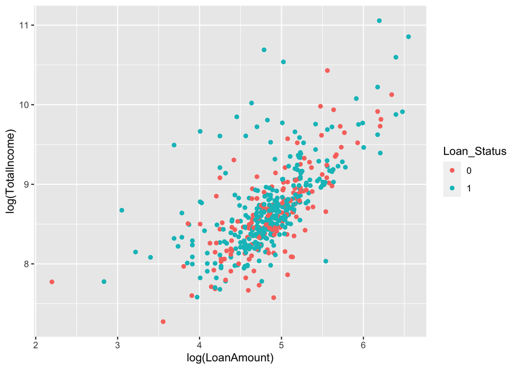

```r
train%>%
  ggplot(aes(x = log(LoanAmount), y= log(TotalIncome), color = Loan_Status)) + geom_point()
```

### lda Cross Validation

predictions with the LDA model are less accurate than if we just used the binary classifier Credit_History to determine weather or not a loan would be approved

```r
# cross validation
ctrl <- trainControl(method = 'repeatedcv', repeats = 11)
```

### lda model results

```r
lda.fit <- train(Loan_Status ~ TotalIncome + LoanAmount,
             data = train,
             method = 'lda',
             trControl = ctrl
             )
test$lda <- predict(lda.fit, test)
confusionMatrix(test$lda, test$Loan_Status)
```

```
## Confusion Matrix and Statistics
##
##           Reference
## Prediction  0  1
##          0  0  0
##          1 33 90
##
##                Accuracy : 0.7317
##                  95% CI : (0.6443, 0.8076)
##     No Information Rate : 0.7317
##     P-Value [Acc > NIR] : 0.5467
##
##                   Kappa : 0
##
##  Mcnemar's Test P-Value : 2.54e-08
##
##             Sensitivity : 0.0000
##             Specificity : 1.0000
##          Pos Pred Value :    NaN
##          Neg Pred Value : 0.7317
##              Prevalence : 0.2683
##          Detection Rate : 0.0000
##    Detection Prevalence : 0.0000
##       Balanced Accuracy : 0.5000
##
##        'Positive' Class : 0
##
```

## 3. K-nearest Neighbor

First off, set seed = 688.

Create training/test partitions by calling createDataPartition. p is set to .8 to mean 80/20 split for train/test set.

Checking the structure of the test set (*knn_test*)

```r
str(knn_test)
```

```
## 'data.frame':    122 obs. of  12 variables:
##  $ Gender          : Factor w/ 2 levels "Female","Male": 2 2 2 2 2 2 2 2 1 2 ...
##  $ Married         : Factor w/ 2 levels "No","Yes": 1 2 2 2 2 1 1 2 2 2 ...
##  $ Dependents      : Factor w/ 4 levels "0","1","2","3": 1 3 2 3 3 2 4 3 2 1 ...
##  $ Education       : Factor w/ 2 levels "Graduate","Not Graduate": 1 1 1 2 2 1 1 1 1 1 ...
##  $ Self_Employed   : Factor w/ 2 levels "No","Yes": 1 2 1 1 1 2 1 1 2 1 ...
##  $ LoanAmount      : num  141 267 349 112 110 106 320 134 286 96 ...
##  $ Loan_Amount_Term: num  360 360 360 360 360 360 360 360 360 360 ...
##  $ Credit_History  : Factor w/ 2 levels "0","1": 2 2 2 1 2 2 2 2 1 2 ...
##  $ Property_Area   : Factor w/ 3 levels "Rural","Semiurban",..: 3 3 2 1 3 1 1 3 3 2 ...
##  $ Loan_Status     : Factor w/ 2 levels "0","1": 2 2 1 1 2 1 1 1 1 2 ...
##  $ LoanAmtPerSalary: num  2350 4929 2718 3328 2603 ...
##  $ TotalIncome     : num  6000 9613 23809 5282 5266 ...
```

### Cross Validation

```r
# cleaning up some parallel computing
# https://stackoverflow.com/questions/25097729/un-register-a-doparallel-cluster
registerDoSEQ()

trControl <- trainControl(method  = "repeatedcv",
                          repeats  = 11)
knn.fit <- train(Loan_Status ~ .,
             method     = "knn",
             tuneGrid   = expand.grid(k = 1:10),
             trControl  = trControl,
             preProcess = c("center","scale"),
             data       = knn_train
             )

knn.fit
```

```
## k-Nearest Neighbors
##
## 492 samples
##  11 predictor
##   2 classes: '0', '1'
##
## Pre-processing: centered (14), scaled (14)
## Resampling: Cross-Validated (10 fold, repeated 11 times)
## Summary of sample sizes: 442, 444, 443, 443, 442, 444, ...
## Resampling results across tuning parameters:
##
##   k   Accuracy   Kappa
##    1  0.7122390  0.3217246
##    2  0.7089797  0.3061592
##    3  0.7694411  0.4090793
##    4  0.7605727  0.3808163
##    5  0.7838922  0.4188985
##    6  0.7732961  0.3882704
##    7  0.7848086  0.4070143
##    8  0.7832899  0.4023703
##    9  0.7912427  0.4176016
##   10  0.7873503  0.4063482
##
## Accuracy was used to select the optimal model using the largest value.
## The final value used for the model was k = 9.
```

#### Key Information on the value of K

Since our target variable is a binary factor of 2, by default, we use Accuracy as the determining performance metric. The optimal K is thus determined by Accuracy. **K = 9 was finally selected.** # of neighbors is 9.

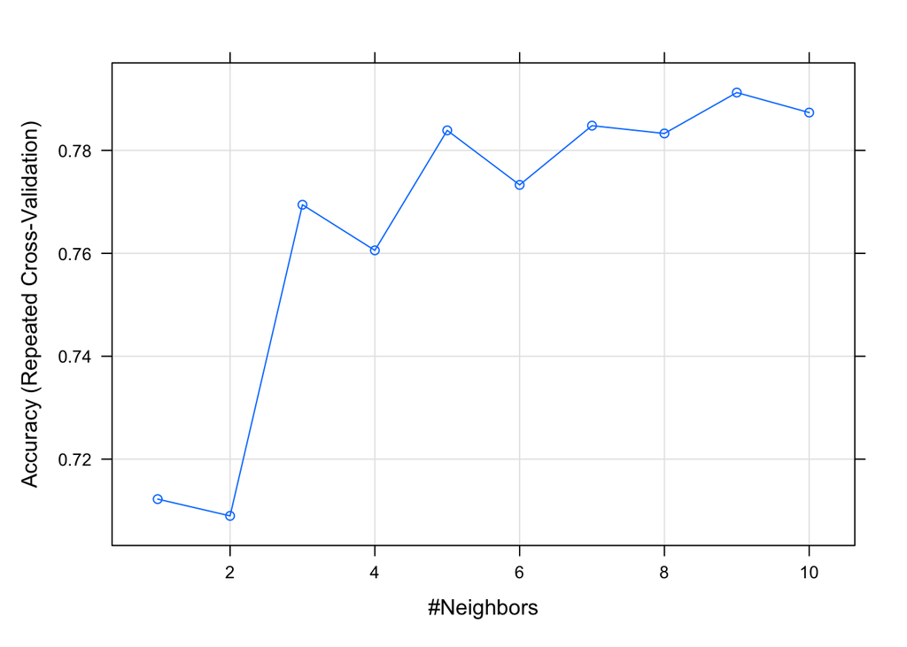

```r
plot(knn.fit)
```

### Model Results

```r
knn_pred <- predict(knn.fit, newdata = knn_test)
# options('max.print' = 100)
# getOption("max.print")
confusionMatrix(knn_pred, knn_test$Loan_Status)
```

```
## Confusion Matrix and Statistics
##
##           Reference
## Prediction  0  1
##          0 15  3
##          1 23 81
##
##                Accuracy : 0.7869
##                  95% CI : (0.7035, 0.8558)
##     No Information Rate : 0.6885
##     P-Value [Acc > NIR] : 0.0104406
##
##                   Kappa : 0.4195
##
##  Mcnemar's Test P-Value : 0.0001944
##
##             Sensitivity : 0.3947
##             Specificity : 0.9643
##          Pos Pred Value : 0.8333
##          Neg Pred Value : 0.7788
##              Prevalence : 0.3115
##          Detection Rate : 0.1230
##    Detection Prevalence : 0.1475
##       Balanced Accuracy : 0.6795
##
##        'Positive' Class : 0
##
```

Accuracy is 78.69% while balanced accuracy is only 67.95%.

## 4. Decision Trees

Now we will use a decision tree to see how well it will perform on our data.  
* Our decision tree starts by splitting users based on their Credit_History. This makes sense based on our exploratory data analysis.  
* Other variables used in the decision tree include LoanAmount, PropertyArea, etc.

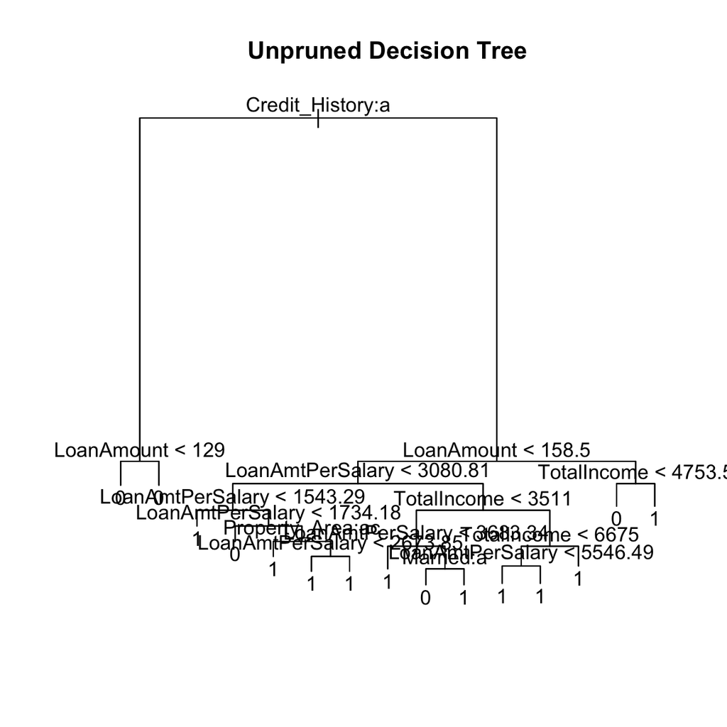

```r
loan_tree = tree(Loan_Status ~., train)
plot(loan_tree)
text(loan_tree)
title(main = "Unpruned Decision Tree")
```

### Decision Tree Performance

#### Training Data

Now we will use our model to see how it performs on the training data. We see that the model predicted **Loan_Status** with an accuracy of ~83%. 81 instances were incorrectly classified.

```r
pred_tree_train <- predict(loan_tree,train,type="class")
test_table <- table(pred_tree_train,train$Loan_Status) %>% kbl() %>% kable_styling()
test_table
```

|  | 0 | 1 |
| --- | --- | --- |
| 0 | 89 | 11 |
| 1 | 70 | 321 |

```r
mean(pred_tree_train == train$Loan_Status)
```

```
## [1] 0.8350305
```

### Cross-validation for better performance

```r
set.seed(2311)
cv_trees = cv.tree(loan_tree,FUN = prune.misclass)
cv_trees
```

```
## $size
## [1] 15 10  4  2  1
##
## $dev
## [1] 108 108 101  97 159
##
## $k
## [1]      -Inf  0.000000  1.333333  2.500000 65.000000
##
## $method
## [1] "misclass"
##
## attr(,"class")
## [1] "prune"         "tree.sequence"
```

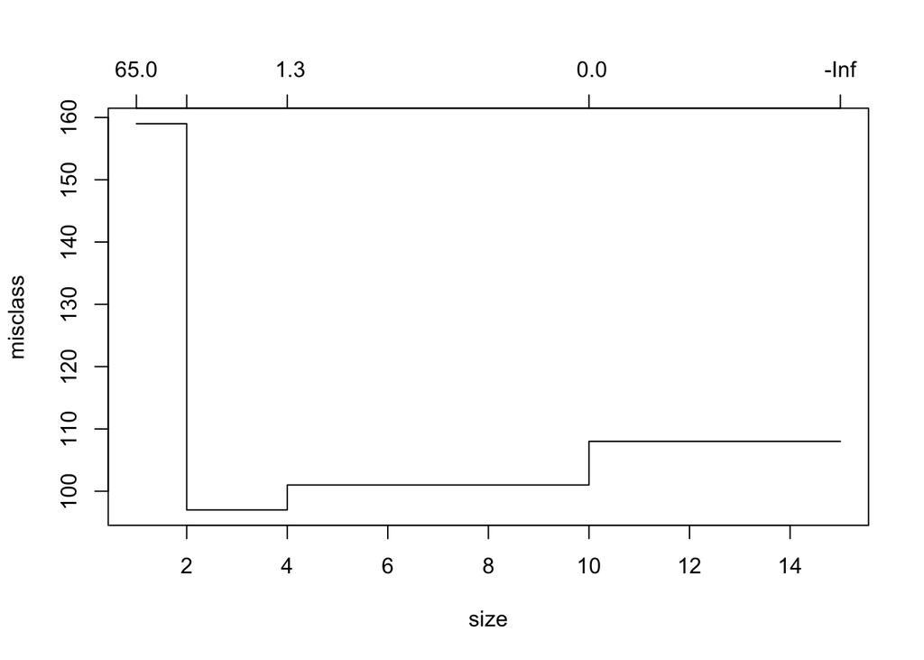

```r
plot(cv_trees)
```

Using a size = 4, our decision tree looks like the following:

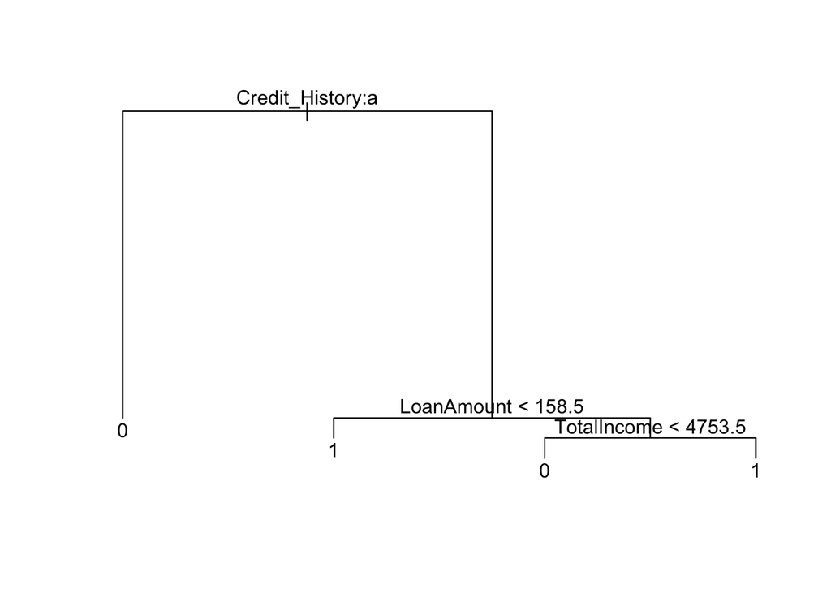

```r
loan_tree_pruned = prune.misclass(loan_tree,best=4)
plot(loan_tree_pruned)
text(loan_tree_pruned)
```

### Testing Data

Now let’s see how our pruned performs on our testing data. The accuracy for our test data was ~82%, which was almost the same as our training data. 21 of the total observations were misclassified.

```r
pred_tree_test  <- predict(loan_tree_pruned,test, type="class")
test_table <- table(pred_tree_test,test$Loan_Status) %>% kbl() %>% kable_styling()
test_table
```

|  | 0 | 1 |
| --- | --- | --- |
| 0 | 14 | 2 |
| 1 | 19 | 88 |

```r
mean(pred_tree_test == test$Loan_Status)
```

```
## [1] 0.8292683
```

```r
confusionMatrix(pred_tree_test, test$Loan_Status)
```

```
## Confusion Matrix and Statistics
##
##           Reference
## Prediction  0  1
##          0 14  2
##          1 19 88
##
##                Accuracy : 0.8293
##                  95% CI : (0.7509, 0.8911)
##     No Information Rate : 0.7317
##     P-Value [Acc > NIR] : 0.0075806
##
##                   Kappa : 0.4804
##
##  Mcnemar's Test P-Value : 0.0004803
##
##             Sensitivity : 0.4242
##             Specificity : 0.9778
##          Pos Pred Value : 0.8750
##          Neg Pred Value : 0.8224
##              Prevalence : 0.2683
##          Detection Rate : 0.1138
##    Detection Prevalence : 0.1301
##       Balanced Accuracy : 0.7010
##
##        'Positive' Class : 0
##
```

## 5. Random Forests

Now we will develop a random forest model to see how well it will performs with our data. Parameters for a random forest include: **mtry** : Number of variables randomly sampled as candidates at each split. Note that the default values are different for classification (sqrt(p) where p is number of variables in x) and regression (p/3) **ntree** : Number of trees to grow. This should not be set to too small a number, to ensure that every input row gets predicted at least a few times

```r
# find out no of cores
no_cores <- detectCores() - 1

cl<-makePSOCKcluster(no_cores)

registerDoParallel(cl)

# start.time<-proc.time()

# model<-train(target~., data=trainingset, method='rf')
```

```r
#drop loan id
train_rf1 <- train
test_rf1 <- test

# Create model with default parameters
control <- trainControl(method="repeatedcv", number=10, repeats=3)
mtry <- sqrt(ncol(train_rf1))
tunegrid <- expand.grid(.mtry=mtry)
rf_default <- train(Loan_Status~., data=train_rf1, method="rf", metric="Accuracy", tuneGrid=tunegrid, trControl=control)
print(rf_default)
```

```
## Random Forest
##
## 491 samples
##  11 predictor
##   2 classes: '0', '1'
##
## No pre-processing
## Resampling: Cross-Validated (10 fold, repeated 3 times)
## Summary of sample sizes: 443, 442, 441, 442, 442, 442, ...
## Resampling results:
##
##   Accuracy   Kappa
##   0.8011678  0.4879166
##
## Tuning parameter 'mtry' was held constant at a value of 3.464102
```

```r
# stop.time<-proc.time()
#
# run.time<-stop.time -start.time
#
# print(run.time)
#
# stopCluster(cl)
```

```r
control <- trainControl(method="repeatedcv", number=10, repeats=3, search="grid")
set.seed(123)
tunegrid <- expand.grid(.mtry=c(1:10))
rf_gridsearch <- train(Loan_Status~., data=train_rf1, method="rf", metric="Accuracy", tuneGrid=tunegrid, trControl=control)
print(rf_gridsearch)
```

```
## Random Forest
##
## 491 samples
##  11 predictor
##   2 classes: '0', '1'
##
## No pre-processing
## Resampling: Cross-Validated (10 fold, repeated 3 times)
## Summary of sample sizes: 442, 442, 441, 442, 442, 441, ...
## Resampling results across tuning parameters:
##
##   mtry  Accuracy   Kappa
##    1    0.6795697  0.0138783
##    2    0.8003464  0.4745384
##    3    0.8030964  0.4913187
##    4    0.7983611  0.4853485
##    5    0.7895170  0.4665550
##    6    0.7874632  0.4625780
##    7    0.7881434  0.4672603
##    8    0.7847562  0.4591980
##    9    0.7846871  0.4605619
##   10    0.7820074  0.4550405
##
## Accuracy was used to select the optimal model using the largest value.
## The final value used for the model was mtry = 3.
```

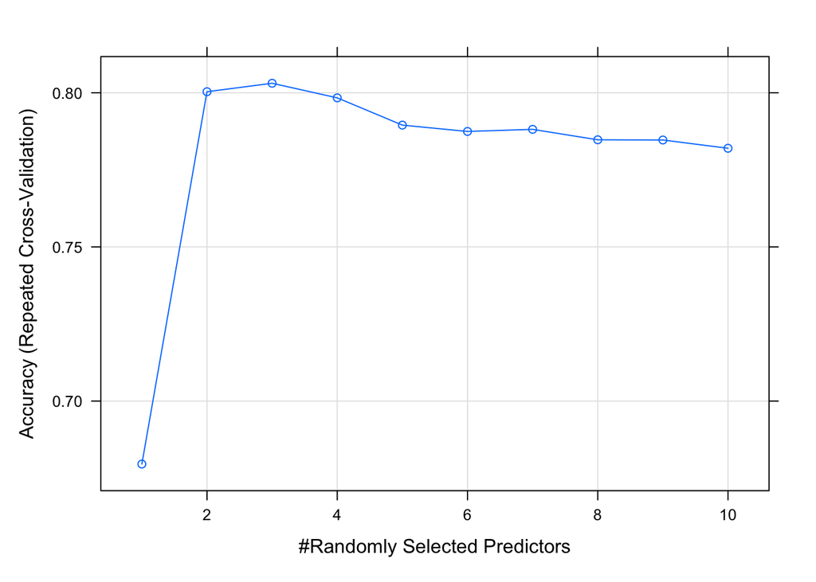

```r
plot(rf_gridsearch)
```

```r
control <- trainControl(method="repeatedcv", number=10, repeats=3, search="grid")
tunegrid <- expand.grid(.mtry=2)
modellist <- list()
for (ntree in c(500, 1000, 1500, 2000, 2500)) {
  set.seed(124)
    fit <- train(Loan_Status~., data=train_rf1, method="rf", metric="Accuracy", tuneGrid=tunegrid, trControl=control, ntree=ntree)
    key <- toString(ntree)
    modellist[[key]] <- fit
}
# compare results
results <- resamples(modellist)
summary(results)
```

```
##
## Call:
## summary.resamples(object = results)
##
## Models: 500, 1000, 1500, 2000, 2500
## Number of resamples: 30
##
## Accuracy
##           Min.   1st Qu.    Median      Mean   3rd Qu.      Max. NA's
## 500  0.7346939 0.7755102 0.7959184 0.8025006 0.8190816 0.8958333    0
## 1000 0.7346939 0.7755102 0.7959184 0.8011400 0.8163265 0.8958333    0
## 1500 0.7346939 0.7755102 0.7959184 0.8018203 0.8163265 0.8979592    0
## 2000 0.7346939 0.7755102 0.7959184 0.8011400 0.8163265 0.8958333    0
## 2500 0.7346939 0.7755102 0.7959184 0.8018203 0.8163265 0.8979592    0
##
## Kappa
##           Min.   1st Qu.    Median      Mean  3rd Qu.      Max. NA's
## 500  0.2669735 0.4038375 0.4688651 0.4828621 0.545829 0.7435897    0
## 1000 0.2669735 0.4035402 0.4688651 0.4794511 0.541709 0.7435897    0
## 1500 0.2669735 0.4035402 0.4688651 0.4813131 0.541709 0.7476828    0
## 2000 0.2669735 0.4035402 0.4688651 0.4794511 0.541709 0.7435897    0
## 2500 0.2669735 0.4035402 0.4688651 0.4813131 0.541709 0.7476828    0
```

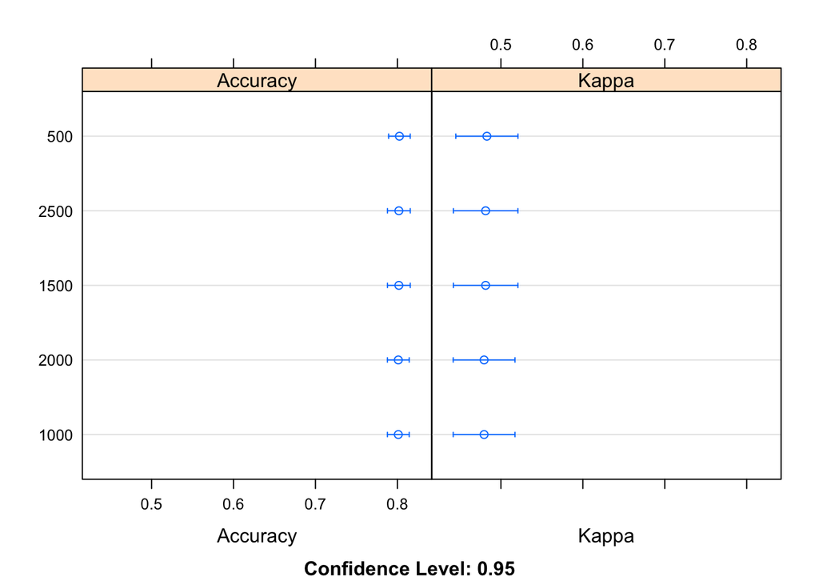

```r
dotplot(results)
```

Our final random forest model will have mtry=2 and ntree=1500.

```r
rf_final <- randomForest(Loan_Status ~ .,
                        data = train_rf1,
                        ntree = 1500,
                        mtry = 2,
                        importance = TRUE,
                        proximity = TRUE)

print(rf_final)
```

```
##
## Call:
##  randomForest(formula = Loan_Status ~ ., data = train_rf1, ntree = 1500,      mtry = 2, importance = TRUE, proximity = TRUE)
##                Type of random forest: classification
##                      Number of trees: 1500
## No. of variables tried at each split: 2
##
##         OOB estimate of  error rate: 20.16%
## Confusion matrix:
##    0   1 class.error
## 0 73  86  0.54088050
## 1 13 319  0.03915663
```

```r
#variable importance
round(importance(rf_final), 2)
```

```
##                      0     1 MeanDecreaseAccuracy MeanDecreaseGini
## Gender           -3.23  7.74                 4.91             3.08
## Married          -3.14  7.90                 5.27             3.78
## Dependents       -4.43 10.80                 6.82             8.80
## Education         0.92  2.94                 3.06             3.91
## Self_Employed    -4.98  8.16                 4.25             3.06
## LoanAmount       -3.72 24.77                20.67            25.34
## Loan_Amount_Term  7.10  9.66                11.98             8.48
## Credit_History   93.68 95.74               104.16            50.51
## Property_Area     1.28  3.23                 3.38             8.43
## LoanAmtPerSalary  3.34 17.43                16.68            27.54
## TotalIncome      -4.38 23.64                19.72            27.19
```

```r
prediction <-predict(rf_final, test_rf1)
confusionMatrix(prediction, test_rf1$Loan_Status)
```

```
## Confusion Matrix and Statistics
##
##           Reference
## Prediction  0  1
##          0 14  1
##          1 19 89
##
##                Accuracy : 0.8374
##                  95% CI : (0.7601, 0.8978)
##     No Information Rate : 0.7317
##     P-Value [Acc > NIR] : 0.0039800
##
##                   Kappa : 0.4994
##
##  Mcnemar's Test P-Value : 0.0001439
##
##             Sensitivity : 0.4242
##             Specificity : 0.9889
##          Pos Pred Value : 0.9333
##          Neg Pred Value : 0.8241
##              Prevalence : 0.2683
##          Detection Rate : 0.1138
##    Detection Prevalence : 0.1220
##       Balanced Accuracy : 0.7066
##
##        'Positive' Class : 0
##
```

```r
# stop.time<-proc.time()

# run.time<-stop.time -start.time

# print(run.time)

# Stopping Cluster
stopCluster(cl)
```

## 6. Model Performance

Model Performance Matrix

| Metric | LDA | K-Nearest Neighbor (KNN) | Decision Trees | Random Forest |
| --- | --- | --- | --- | --- |
| Accuracy | 0.7317 | 0.7869 | 0.8293 | 0.8374 |
| Balanced Accuracy | 0.5000 | 0.6795 | 0.7010 | 0.7066 |
| Sensitivity | 0 | 0.3947 | 0.4242 | 0.4242 |